# Cell annotation refinement

## Cell annotation refinement

Here, the cell type annotations generated using the 10x Genomics label transfer workflow were further refined (https://www.10xgenomics.com/analysis-guides/xenium-cell-type-annotation).

In particular, the Ciliated Epithelial Cells population was re-evaluated because a substantial proportion of these cells were located outside the histologically normal fallopian tube epithelium.

In addition, Secretory Epithelial Cells were identified within the Fallopian Tube Epithelium population and annotated as a separate cell type.

## Load libraries

```r
# load libraries
library(Seurat)
library(tidyverse)
library(ggplot2)
library(dplyr)
library(knitr)
library(clusterProfiler)
library(org.Hs.eg.db)
library(AnnotationDbi)
library(enrichR)
library(kableExtra)
library(stringr)
```

## Import data

Here, the Xenium object resulting from the “Annotating Cell Types in Xenium In Situ Data with Label Transfer” pipeline is imported (https://www.10xgenomics.com/analysis-guides/xenium-cell-type-annotation).

```r
# Import Xenium annotated data
xenium.obj <- readRDS("Data/xenium.obj_annotated_scores.rds")

# palettes
custom_hex <- c("#3375AB", "#FFFF00", "#E8280E", "#8D1909", "#E47E11","#FF75A0", "#19297C", "#AC674E", "#805D93", "#13B0F7", "#8980F5", "#595959", "#0BFFFF", "#169873", "#8EE525", "#169873", "#52E097", "#8980F5", "#EE00B0")

names(custom_hex) <- c("Tumor Associated Fibroblasts", "Malignant Cells Lining Cyst", "Tumor Cells", "Inflammatory Tumor Cells", "Proliferative Tumor Cells", "VEGFA+ Tumor Cells", "Stromal Associated Fibroblasts", "Endothelial Cells", "Stromal Associated Macrophages", "Smooth Muscle Cells", "Tumor Associated Macrophages", "T & NK Cells", "Pericytes", "Granulosa and FT Epithelial Cells", "Ciliated Epithelial Cells", "Granulosa Cells", "Fallopian Tube Epithelium", "Macrophages", "MT-High, Jun+/Fos+ Tumor Cells")
```

## Top markers

Show top 15 markers for each annotated cell type.

```r
markers_entire <- FindAllMarkers(
  xenium.obj,
  only.pos = TRUE,
  assay = "Xenium",
  group.by = "cell_type",
  slot = "data",
  test.use = "wilcox"
)

top15_markers <- markers_entire %>%
  group_by(cluster) %>%
  slice_max(order_by = avg_log2FC, n = 15)

cell_types <- sort(unique(top15_markers$cluster))

for (ct in cell_types) {

  cat("### ", ct, "\n\n", sep = "")

  print(
    kable(
      top15_markers %>%
        filter(cluster == ct) %>%
        dplyr::select(
          gene,
          avg_log2FC,
          p_val_adj
        ),
      digits = 3
    )
  )

  cat("\n\n")
}
```

### Proliferative Tumor Cells

| cluster | gene | avg_log2FC | p_val_adj |
| --- | --- | --- | --- |
| Proliferative Tumor Cells | RAD54L | 2.735 | 0 |
| Proliferative Tumor Cells | MYBL2 | 2.689 | 0 |
| Proliferative Tumor Cells | TYMS | 2.523 | 0 |
| Proliferative Tumor Cells | BIRC5 | 2.468 | 0 |
| Proliferative Tumor Cells | FOXM1 | 2.440 | 0 |
| Proliferative Tumor Cells | TOP2A | 2.439 | 0 |
| Proliferative Tumor Cells | CDK1 | 2.432 | 0 |
| Proliferative Tumor Cells | AURKB | 2.420 | 0 |
| Proliferative Tumor Cells | MELK | 2.416 | 0 |
| Proliferative Tumor Cells | KIF18B | 2.351 | 0 |
| Proliferative Tumor Cells | PBK | 2.329 | 0 |
| Proliferative Tumor Cells | BUB1 | 2.316 | 0 |
| Proliferative Tumor Cells | TPX2 | 2.298 | 0 |
| Proliferative Tumor Cells | ASPM | 2.293 | 0 |
| Proliferative Tumor Cells | ASF1B | 2.285 | 0 |

### MT-High, Jun+/Fos+ Tumor Cells

| cluster | gene | avg_log2FC | p_val_adj |
| --- | --- | --- | --- |
| MT-High, Jun+/Fos+ Tumor Cells | C2orf88 | 1.461 | 0.000 |
| MT-High, Jun+/Fos+ Tumor Cells | KIAA1324 | 1.446 | 0.000 |
| MT-High, Jun+/Fos+ Tumor Cells | UGT2B7 | 1.435 | 0.000 |
| MT-High, Jun+/Fos+ Tumor Cells | PART1 | 1.395 | 0.000 |
| MT-High, Jun+/Fos+ Tumor Cells | TUBB4A | 1.355 | 0.000 |
| MT-High, Jun+/Fos+ Tumor Cells | DOK7 | 1.327 | 0.000 |
| MT-High, Jun+/Fos+ Tumor Cells | KCNK15 | 1.313 | 0.000 |
| MT-High, Jun+/Fos+ Tumor Cells | SOX9 | 1.287 | 0.000 |
| MT-High, Jun+/Fos+ Tumor Cells | PRNCR1 | 1.274 | 1.000 |
| MT-High, Jun+/Fos+ Tumor Cells | SMPDL3B | 1.268 | 0.000 |
| MT-High, Jun+/Fos+ Tumor Cells | MSLN | 1.265 | 0.000 |
| MT-High, Jun+/Fos+ Tumor Cells | POTEF | 1.258 | 0.000 |
| MT-High, Jun+/Fos+ Tumor Cells | PPP1R1C | 1.240 | 0.000 |
| MT-High, Jun+/Fos+ Tumor Cells | CRB2 | 1.229 | 0.000 |
| MT-High, Jun+/Fos+ Tumor Cells | PCAT1 | 1.227 | 0.041 |

### VEGFA+ Tumor Cells

| cluster | gene | avg_log2FC | p_val_adj |
| --- | --- | --- | --- |
| VEGFA+ Tumor Cells | TOP2A | 2.488 | 0 |
| VEGFA+ Tumor Cells | EREG | 2.287 | 0 |
| VEGFA+ Tumor Cells | NMU | 2.285 | 0 |
| VEGFA+ Tumor Cells | NEK2 | 2.251 | 0 |
| VEGFA+ Tumor Cells | BUB1 | 2.251 | 0 |
| VEGFA+ Tumor Cells | TPX2 | 2.218 | 0 |
| VEGFA+ Tumor Cells | UBE2C | 2.214 | 0 |
| VEGFA+ Tumor Cells | CDC20 | 2.212 | 0 |
| VEGFA+ Tumor Cells | TFPI2 | 2.202 | 0 |
| VEGFA+ Tumor Cells | CENPF | 2.198 | 0 |
| VEGFA+ Tumor Cells | CDCA2 | 2.198 | 0 |
| VEGFA+ Tumor Cells | CENPA | 2.164 | 0 |
| VEGFA+ Tumor Cells | ASPM | 2.148 | 0 |
| VEGFA+ Tumor Cells | TNFRSF11B | 2.133 | 0 |
| VEGFA+ Tumor Cells | SLC2A1 | 2.085 | 0 |

### Tumor Cells

| cluster | gene | avg_log2FC | p_val_adj |
| --- | --- | --- | --- |
| Tumor Cells | PCP2 | 2.747 | 0 |
| Tumor Cells | BMP6 | 2.321 | 0 |
| Tumor Cells | MAPK15 | 2.224 | 0 |
| Tumor Cells | KCNK15 | 2.223 | 0 |
| Tumor Cells | CFAP47 | 2.180 | 0 |
| Tumor Cells | FAM107A | 2.088 | 0 |
| Tumor Cells | KCNC3 | 2.029 | 0 |
| Tumor Cells | DACH1 | 2.017 | 0 |
| Tumor Cells | PKD1L1 | 1.993 | 0 |
| Tumor Cells | PART1 | 1.966 | 0 |
| Tumor Cells | APELA | 1.954 | 0 |
| Tumor Cells | EPOR | 1.933 | 0 |
| Tumor Cells | KIAA1324 | 1.880 | 0 |
| Tumor Cells | TNNT2 | 1.844 | 0 |
| Tumor Cells | CRB2 | 1.824 | 0 |

### Macrophages

| cluster | gene | avg_log2FC | p_val_adj |
| --- | --- | --- | --- |
| Macrophages | MRC1 | 6.015 | 0 |
| Macrophages | CD163 | 5.720 | 0 |
| Macrophages | F13A1 | 5.663 | 0 |
| Macrophages | CSF1R | 5.427 | 0 |
| Macrophages | STAB1 | 5.295 | 0 |
| Macrophages | LILRB5 | 5.279 | 0 |
| Macrophages | CYBB | 5.184 | 0 |
| Macrophages | CD14 | 5.142 | 0 |
| Macrophages | SIGLEC1 | 5.075 | 0 |
| Macrophages | FCGBP | 5.062 | 0 |
| Macrophages | C1QC | 4.997 | 0 |
| Macrophages | SLCO2B1 | 4.974 | 0 |
| Macrophages | VSIG4 | 4.953 | 0 |
| Macrophages | LAIR1 | 4.949 | 0 |
| Macrophages | MS4A6A | 4.888 | 0 |

### Ciliated Epithelial Cells

| cluster | gene | avg_log2FC | p_val_adj |
| --- | --- | --- | --- |
| Ciliated Epithelial Cells | C20orf85 | 8.123 | 0 |
| Ciliated Epithelial Cells | CFAP100 | 6.677 | 0 |
| Ciliated Epithelial Cells | CDHR4 | 6.670 | 0 |
| Ciliated Epithelial Cells | FAM216B | 6.605 | 0 |
| Ciliated Epithelial Cells | TEKT1 | 6.501 | 0 |
| Ciliated Epithelial Cells | LDLRAD1 | 6.454 | 0 |
| Ciliated Epithelial Cells | FAM183A | 6.392 | 0 |
| Ciliated Epithelial Cells | ERICH3 | 6.161 | 0 |
| Ciliated Epithelial Cells | DNAH11 | 6.016 | 0 |
| Ciliated Epithelial Cells | TPPP3 | 5.815 | 0 |
| Ciliated Epithelial Cells | IL5RA | 5.704 | 0 |
| Ciliated Epithelial Cells | DNAH10 | 5.682 | 0 |
| Ciliated Epithelial Cells | CFAP47 | 5.629 | 0 |
| Ciliated Epithelial Cells | SRD5A2 | 5.567 | 0 |
| Ciliated Epithelial Cells | DNAI1 | 5.520 | 0 |

### T & NK Cells

| cluster | gene | avg_log2FC | p_val_adj |
| --- | --- | --- | --- |
| T & NK Cells | CD8A | 7.463 | 0 |
| T & NK Cells | TRBC1 | 7.438 | 0 |
| T & NK Cells | TRAC | 6.802 | 0 |
| T & NK Cells | CD2 | 6.685 | 0 |
| T & NK Cells | CD3E | 6.474 | 0 |
| T & NK Cells | GZMA | 6.403 | 0 |
| T & NK Cells | CD52 | 6.373 | 0 |
| T & NK Cells | CD3D | 6.131 | 0 |
| T & NK Cells | IL7R | 6.022 | 0 |
| T & NK Cells | GZMH | 5.898 | 0 |
| T & NK Cells | SH2D1A | 5.766 | 0 |
| T & NK Cells | KLRK1 | 5.756 | 0 |
| T & NK Cells | GPR174 | 5.649 | 0 |
| T & NK Cells | GZMK | 5.547 | 0 |
| T & NK Cells | CD96 | 5.486 | 0 |

### Tumor Associated Fibroblasts

| cluster | gene | avg_log2FC | p_val_adj |
| --- | --- | --- | --- |
| Tumor Associated Fibroblasts | COL11A1 | 5.985 | 0 |
| Tumor Associated Fibroblasts | COL10A1 | 5.630 | 0 |
| Tumor Associated Fibroblasts | INHBA | 5.326 | 0 |
| Tumor Associated Fibroblasts | MMP11 | 5.226 | 0 |
| Tumor Associated Fibroblasts | CTHRC1 | 5.006 | 0 |
| Tumor Associated Fibroblasts | COMP | 5.005 | 0 |
| Tumor Associated Fibroblasts | CDH11 | 4.744 | 0 |
| Tumor Associated Fibroblasts | ADAMTS14 | 4.568 | 0 |
| Tumor Associated Fibroblasts | SERPINE1 | 4.541 | 0 |
| Tumor Associated Fibroblasts | ADAM12 | 4.491 | 0 |
| Tumor Associated Fibroblasts | LOXL1 | 4.483 | 0 |
| Tumor Associated Fibroblasts | SCG2 | 4.385 | 0 |
| Tumor Associated Fibroblasts | COL5A2 | 4.350 | 0 |
| Tumor Associated Fibroblasts | FAP | 4.291 | 0 |
| Tumor Associated Fibroblasts | LUM | 4.181 | 0 |

### Malignant Cells Lining Cyst

| cluster | gene | avg_log2FC | p_val_adj |
| --- | --- | --- | --- |
| Malignant Cells Lining Cyst | PRG4 | 8.054 | 0 |
| Malignant Cells Lining Cyst | CPA4 | 6.637 | 0 |
| Malignant Cells Lining Cyst | CALB2 | 6.429 | 0 |
| Malignant Cells Lining Cyst | BNC1 | 5.850 | 0 |
| Malignant Cells Lining Cyst | PAEP | 4.941 | 0 |
| Malignant Cells Lining Cyst | ANXA8 | 4.922 | 0 |
| Malignant Cells Lining Cyst | RGS4 | 4.921 | 0 |
| Malignant Cells Lining Cyst | UPK3B | 4.865 | 0 |
| Malignant Cells Lining Cyst | PROCR | 4.718 | 0 |
| Malignant Cells Lining Cyst | LRP2 | 4.525 | 0 |
| Malignant Cells Lining Cyst | PTGER3 | 4.460 | 0 |
| Malignant Cells Lining Cyst | TGM1 | 4.214 | 0 |
| Malignant Cells Lining Cyst | DSC3 | 4.061 | 0 |
| Malignant Cells Lining Cyst | CLDN1 | 4.040 | 0 |
| Malignant Cells Lining Cyst | FGF1 | 3.945 | 0 |

### Endothelial Cells

| cluster | gene | avg_log2FC | p_val_adj |
| --- | --- | --- | --- |
| Endothelial Cells | CLDN5 | 7.105 | 0 |
| Endothelial Cells | CCL14 | 6.534 | 0 |
| Endothelial Cells | SELP | 6.491 | 0 |
| Endothelial Cells | PTPRB | 6.353 | 0 |
| Endothelial Cells | CLEC14A | 6.242 | 0 |
| Endothelial Cells | EGFL7 | 6.208 | 0 |
| Endothelial Cells | TEK | 6.044 | 0 |
| Endothelial Cells | TIE1 | 6.028 | 0 |
| Endothelial Cells | FLT4 | 6.023 | 0 |
| Endothelial Cells | ROBO4 | 6.005 | 0 |
| Endothelial Cells | ADGRL4 | 5.995 | 0 |
| Endothelial Cells | NOTCH4 | 5.954 | 0 |
| Endothelial Cells | CDH5 | 5.910 | 0 |
| Endothelial Cells | SHANK3 | 5.903 | 0 |
| Endothelial Cells | MMRN2 | 5.877 | 0 |

### Fallopian Tube Epithelium

| cluster | gene | avg_log2FC | p_val_adj |
| --- | --- | --- | --- |
| Fallopian Tube Epithelium | PAX2 | 5.498 | 0 |
| Fallopian Tube Epithelium | CD22 | 4.930 | 0 |
| Fallopian Tube Epithelium | ERP27 | 4.804 | 0 |
| Fallopian Tube Epithelium | WDR72 | 4.794 | 0 |
| Fallopian Tube Epithelium | LGR5 | 4.550 | 0 |
| Fallopian Tube Epithelium | AC007906.2 | 4.310 | 0 |
| Fallopian Tube Epithelium | HNF1B | 4.174 | 0 |
| Fallopian Tube Epithelium | SLITRK5 | 4.145 | 0 |
| Fallopian Tube Epithelium | CDH16 | 4.048 | 0 |
| Fallopian Tube Epithelium | ADCYAP1R1 | 3.767 | 0 |
| Fallopian Tube Epithelium | PPP1R1B | 3.586 | 0 |
| Fallopian Tube Epithelium | MLXIPL | 3.572 | 0 |
| Fallopian Tube Epithelium | S100A1 | 3.557 | 0 |
| Fallopian Tube Epithelium | TMEM45B | 3.506 | 0 |
| Fallopian Tube Epithelium | MLPH | 3.375 | 0 |

### Stromal Associated Fibroblasts

| cluster | gene | avg_log2FC | p_val_adj |
| --- | --- | --- | --- |
| Stromal Associated Fibroblasts | ABCA10 | 6.371 | 0 |
| Stromal Associated Fibroblasts | C7 | 5.227 | 0 |
| Stromal Associated Fibroblasts | TNXB | 5.047 | 0 |
| Stromal Associated Fibroblasts | ABCA8 | 5.039 | 0 |
| Stromal Associated Fibroblasts | DPT | 4.692 | 0 |
| Stromal Associated Fibroblasts | SRPX | 4.651 | 0 |
| Stromal Associated Fibroblasts | PI16 | 4.538 | 0 |
| Stromal Associated Fibroblasts | FAIM2 | 4.532 | 0 |
| Stromal Associated Fibroblasts | PAMR1 | 4.415 | 0 |
| Stromal Associated Fibroblasts | SVEP1 | 4.300 | 0 |
| Stromal Associated Fibroblasts | F3 | 4.011 | 0 |
| Stromal Associated Fibroblasts | SCN7A | 3.840 | 0 |
| Stromal Associated Fibroblasts | COL4A4 | 3.764 | 0 |
| Stromal Associated Fibroblasts | ADM | 3.753 | 0 |
| Stromal Associated Fibroblasts | AOX1 | 3.700 | 0 |

### Pericytes

| cluster | gene | avg_log2FC | p_val_adj |
| --- | --- | --- | --- |
| Pericytes | AVPR1A | 5.352 | 0 |
| Pericytes | STEAP4 | 4.612 | 0 |
| Pericytes | TBX2 | 4.446 | 0 |
| Pericytes | CCDC102B | 4.129 | 0 |
| Pericytes | ENPEP | 4.107 | 0 |
| Pericytes | HEYL | 4.055 | 0 |
| Pericytes | TINAGL1 | 3.853 | 0 |
| Pericytes | KCNJ8 | 3.838 | 0 |
| Pericytes | CCL19 | 3.795 | 0 |
| Pericytes | CNR1 | 3.791 | 0 |
| Pericytes | PARM1 | 3.702 | 0 |
| Pericytes | PGF | 3.669 | 0 |
| Pericytes | WFDC1 | 3.651 | 0 |
| Pericytes | GJC1 | 3.639 | 0 |
| Pericytes | KCNK17 | 3.626 | 0 |

### Smooth Muscle Cells

| cluster | gene | avg_log2FC | p_val_adj |
| --- | --- | --- | --- |
| Smooth Muscle Cells | CNN1 | 6.592 | 0 |
| Smooth Muscle Cells | GRIA2 | 5.571 | 0 |
| Smooth Muscle Cells | PLN | 5.250 | 0 |
| Smooth Muscle Cells | MYH11 | 5.180 | 0 |
| Smooth Muscle Cells | SYNM | 4.661 | 0 |
| Smooth Muscle Cells | MAOB | 4.612 | 0 |
| Smooth Muscle Cells | SMTN | 4.301 | 0 |
| Smooth Muscle Cells | C11orf96 | 4.271 | 0 |
| Smooth Muscle Cells | CACNA1H | 4.101 | 0 |
| Smooth Muscle Cells | MYLK | 4.029 | 0 |
| Smooth Muscle Cells | PLIN4 | 4.004 | 0 |
| Smooth Muscle Cells | JPH2 | 3.963 | 0 |
| Smooth Muscle Cells | CSRP1 | 3.916 | 0 |
| Smooth Muscle Cells | IGSF9B | 3.828 | 0 |
| Smooth Muscle Cells | SYNPO2 | 3.823 | 0 |

### Inflammatory Tumor Cells

| cluster | gene | avg_log2FC | p_val_adj |
| --- | --- | --- | --- |
| Inflammatory Tumor Cells | CXCL10 | 5.984 | 0 |
| Inflammatory Tumor Cells | IFIT1 | 5.581 | 0 |
| Inflammatory Tumor Cells | MX1 | 5.115 | 0 |
| Inflammatory Tumor Cells | RSAD2 | 4.726 | 0 |
| Inflammatory Tumor Cells | LAMP3 | 4.644 | 0 |
| Inflammatory Tumor Cells | IFI44L | 4.620 | 0 |
| Inflammatory Tumor Cells | IFIT3 | 4.470 | 0 |
| Inflammatory Tumor Cells | OAS1 | 4.285 | 0 |
| Inflammatory Tumor Cells | SAMD9 | 4.202 | 0 |
| Inflammatory Tumor Cells | DDX58 | 4.127 | 0 |
| Inflammatory Tumor Cells | OAS3 | 4.104 | 0 |
| Inflammatory Tumor Cells | IFIT2 | 4.077 | 0 |
| Inflammatory Tumor Cells | GBP1 | 3.657 | 0 |
| Inflammatory Tumor Cells | CXCL11 | 3.602 | 0 |
| Inflammatory Tumor Cells | IFIH1 | 3.528 | 0 |

### Granulosa Cells

| cluster | gene | avg_log2FC | p_val_adj |
| --- | --- | --- | --- |
| Granulosa Cells | TNS4 | 7.506 | 0 |
| Granulosa Cells | GABRP | 6.316 | 0 |
| Granulosa Cells | TRIM29 | 6.070 | 0 |
| Granulosa Cells | FGFR3 | 5.834 | 0 |
| Granulosa Cells | AGR2 | 5.806 | 0 |
| Granulosa Cells | ANXA8 | 5.661 | 0 |
| Granulosa Cells | MUC4 | 5.344 | 0 |
| Granulosa Cells | DSG3 | 5.291 | 0 |
| Granulosa Cells | FAT2 | 4.902 | 0 |
| Granulosa Cells | NECTIN1 | 4.868 | 0 |
| Granulosa Cells | DSC3 | 4.867 | 0 |
| Granulosa Cells | CEACAM5 | 4.774 | 0 |
| Granulosa Cells | CYP3A5 | 4.773 | 0 |
| Granulosa Cells | BARX2 | 4.724 | 0 |
| Granulosa Cells | FOXA1 | 4.706 | 0 |

## Assess annotation of Ciliated Epithelial Cells

The UMAP projections and spatial distribution for Ciliated Epithelial Cells were assessed to determine whether this population represented a biologically coherent cell type.

```r
# Plot of full dataset UMAP annotated with cell_type label transfer
DimPlot_full <- DimPlot(
  xenium.obj,
  reduction = "full.umap",
  group.by = "cell_type",
  label = TRUE,
  label.size = 3,
  cols = custom_hex,
  raster = TRUE) +
  guides(colour = guide_legend(override.aes = list(size = 2))) +
  theme(legend.title = element_blank(), legend.text = element_text(size = 7))

# Highlight Ciliated Epithelial Cell cluster only
DimPlot_ciliated <- DimPlot(xenium.obj,
                            reduction = "full.umap",
                            cells.highlight = list(
                              "Ciliated Epithelial Cells" =
                                rownames(subset(xenium.obj@meta.data, cell_type == "Ciliated Epithelial Cells"))),
                            cols.highlight = "#8EE525",
                            cols = "grey90",
                            raster = TRUE) +
  guides(colour = guide_legend(override.aes = list(size = 2))) +
  theme(legend.title = element_blank(), legend.text = element_text(size = 7))

# Create dataframe for ggplot2
df <- cbind(xenium.obj@meta.data,
            GetTissueCoordinates(xenium.obj, image = "fov"))

# Highlight spatial location of ciliated epithelial cells only
Spatial_ciliated <- ggplot(df, aes(x = x, y = y,
                                   colour = ifelse(cell_type == "Ciliated Epithelial Cells",
                                                   "Ciliated Epithelial Cells",
                                                   "Other"))) +
  geom_point(size = 0.3, stroke = 0) +
  coord_equal() +
  scale_y_reverse() +
  scale_color_manual(values = c("Other" = "grey90", "Ciliated Epithelial Cells" = "black")) +
  theme_void() +
  theme(legend.title = element_blank())
```

### Plots

#### Full dataset UMAP

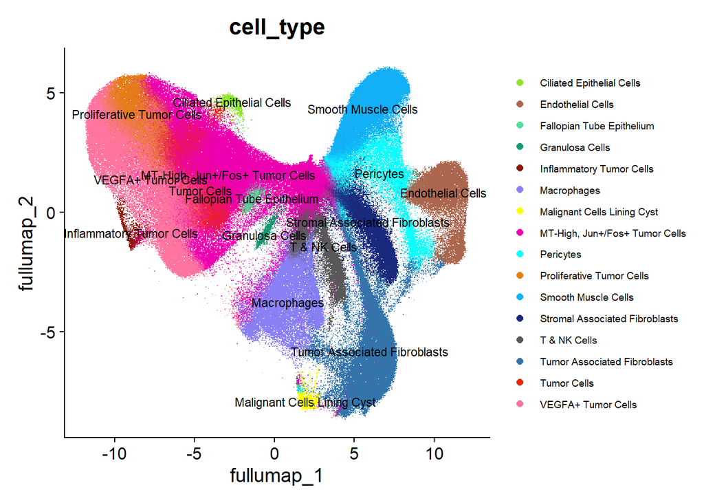

```r
DimPlot_full
```

#### Ciliated Epithelial Cells UMAP

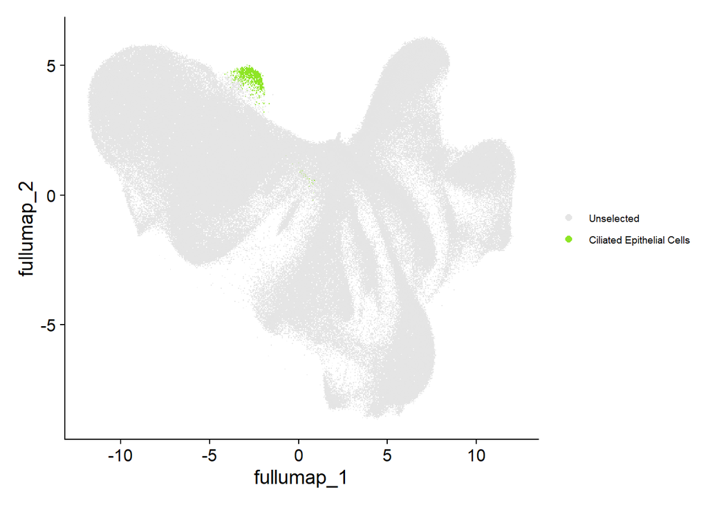

```r
DimPlot_ciliated
```

#### Ciliated Epithelial Cells Spatial plot

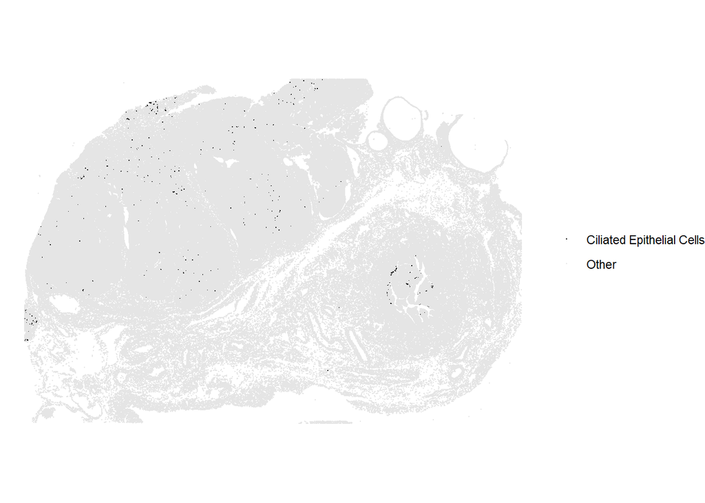

```r
Spatial_ciliated
```

## Label transfer prediction scores

Label transfer prediction scores were examined to assess the confidence of the Ciliated Epithelial Cells annotations.

```r
# Show spatial plot with binary label transfer prediction score thresholding
# Create dataframe
df$ciliated_epithelial_cells <- NA

df$ciliated_epithelial_cells[df$cell_type == "Ciliated Epithelial Cells" & df$predicted.id_full.score >= 0.9] <- ">=0.9"

df$ciliated_epithelial_cells[df$cell_type == "Ciliated Epithelial Cells" & df$predicted.id_full.score < 0.9] <- "<0.9"

cilia_df <- subset(df, cell_type == "Ciliated Epithelial Cells")

# Plot label transfer prediction score in ciliated epithelial population
scores_plot <- ggplot(cilia_df,aes(x = x, y = y, colour = predicted.id_full.score)) +
  geom_point(size = 0.4) +
  coord_equal() +
  scale_y_reverse() +
  scale_colour_viridis_c(limits = c(0,1)) +
  theme_void() +
  ggtitle("Ciliated epithelial cells: Label transfer prediction score")

# Violin plot of label transfer prediction scores
violin_plot <- ggplot(cilia_df,  aes(x = "Ciliated Epithelial Cells", y = predicted.id_full.score)) +
  geom_violin(fill = "#8EE525") +
  # geom_boxplot() +
  theme_classic() +
  xlab("") +
  ylab("label prediction score") +
  ggtitle("Label transfer prediction scores")

# Entire tissue overlay
df$highlight <- "Other"

df$highlight[df$cell_type == "Ciliated Epithelial Cells" & df$predicted.id_full.score >= 0.9] <- "Ciliated >=0.9"

df$highlight[df$cell_type == "Ciliated Epithelial Cells" & df$predicted.id_full.score < 0.9] <- "Ciliated <0.9"

binary_plot <- ggplot() +
  geom_point(data = subset(df, highlight == "Other"),
             aes(x = x, y = y, color = "Other"),
             size = 0.4) +
  geom_point(data = subset(df, highlight == "Ciliated >=0.9"),
             aes(x = x, y = y, color = "Ciliated >=0.9"),
             size = 0.4) +
  geom_point(data = subset(df, highlight == "Ciliated <0.9"),
             aes(x = x, y = y, color = "Ciliated <0.9"),
             size = 0.4) +
  scale_color_manual(name = "Cell type",
                     values = c("Other" = "grey90",
                                "Ciliated >=0.9" = "darkgreen",
                                "Ciliated <0.9" = "red")) +
  coord_equal() +
  scale_y_reverse() +
  theme_void() +
  ggtitle("Spatial distribution of ciliated epithelial cells by prediction score")
```

### Plots

#### Label transfer prediction scores Ciliated

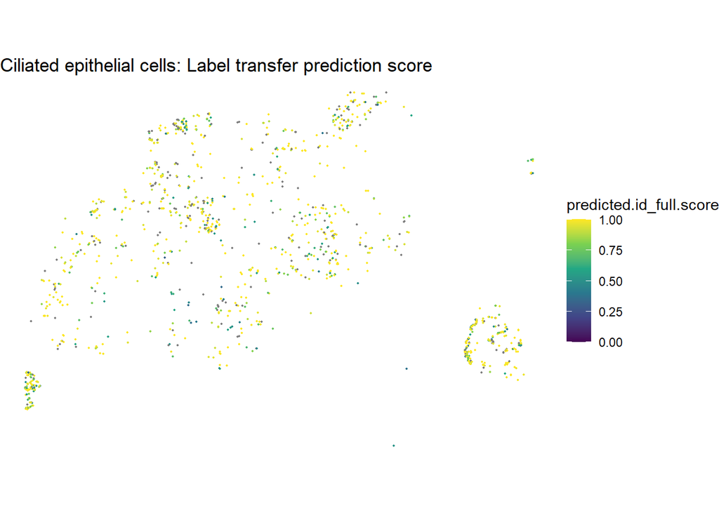

```r
scores_plot
```

#### Violin plot label transfer prediction scores

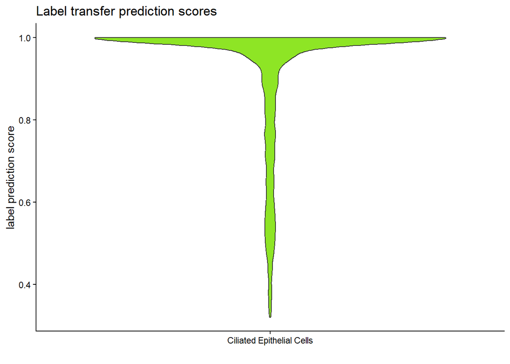

```r
violin_plot
```

#### Threshold plot

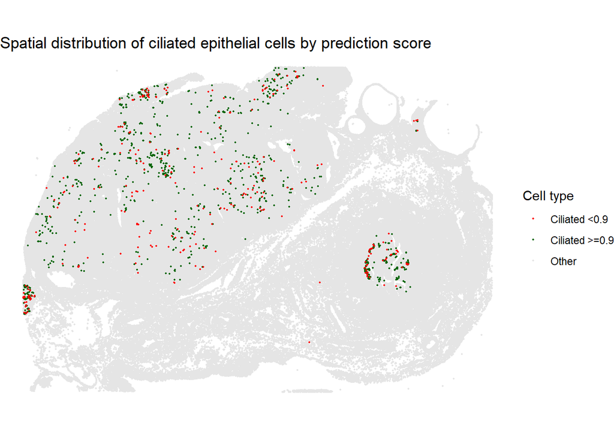

```r
binary_plot
```

## Subclusters

Ciliated Epithelial Cells were subclustered to determine whether distinct populations could explain the observed separation between cells located within and outside the histologically normal fallopian tube region.

```r
# Recompute UMAP on subset to identify subpopulations
# Subset object
cilia_obj <- subset(xenium.obj, subset = cell_type == "Ciliated Epithelial Cells")

DefaultAssay(cilia_obj) <- "Xenium"

cilia_obj <- cilia_obj %>%
  NormalizeData() %>%
  FindVariableFeatures() %>%
  ScaleData() %>%
  RunPCA(npcs = 20) %>%
  FindNeighbors(dims = 1:15) %>%
  FindClusters(resolution = 0.1) %>%
  RunUMAP(dims = 1:15)
```

```
## Modularity Optimizer version 1.3.0 by Ludo Waltman and Nees Jan van Eck
##
## Number of nodes: 1291
## Number of edges: 51431
##
## Running Louvain algorithm...
## Maximum modularity in 10 random starts: 0.9152
## Number of communities: 2
## Elapsed time: 0 seconds
```

```r
# UMAP of identified clusters
UMAP_subclusters <- DimPlot(cilia_obj,  group.by = "seurat_clusters",  label = TRUE) # two clusters are identified at res = 0.1

# Extract coordinates and metadata
df_cilia <- cbind(cilia_obj@meta.data, GetTissueCoordinates(cilia_obj, image = "fov"))

# Plot spatial location of clusters
spatial_subclusters <- ggplot(df_cilia, aes(x = x, y = y, colour = seurat_clusters)) +
  geom_point(size = 0.4, stroke = 0) +
  coord_equal() +
  scale_y_reverse() +
  theme_void() +
  labs(colour = "Cluster")

# Highlight cluster 0 only
cluster0_plot <- ggplot(df_cilia,aes(x = x, y = y,  colour = seurat_clusters == "0")) +
  geom_point(size = 0.4, stroke = 0) +
  coord_equal() +
  scale_y_reverse() +
  scale_color_manual(
    values = c("FALSE" = "grey90",
               "TRUE" = "red"),
    labels = c("Other cluster",
               "Cluster 0")) +
  theme_void() +
  labs(colour = NULL)

# Highlight cluster 1 only
cluster1_plot <- ggplot(df_cilia,aes(x = x, y = y,  colour = seurat_clusters == "1")) +
  geom_point(size = 0.4, stroke = 0) +
  coord_equal() +
  scale_y_reverse() +
  scale_color_manual(values = c("FALSE" = "grey90",
                                "TRUE" = "red"),
                     labels = c("Other cluster",
                                "Cluster 1")) +
  theme_void() +
  labs(colour = NULL)
```

### Plots

#### UMAP subclusters

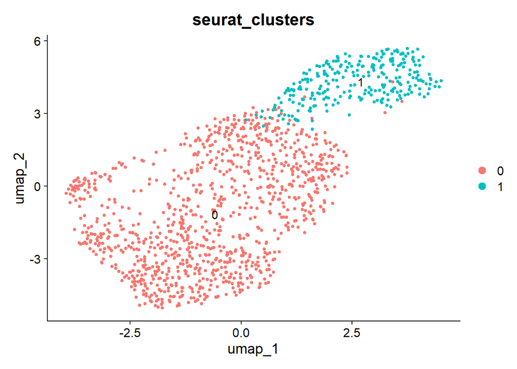

```r
UMAP_subclusters
```

#### Spatial location subclusters

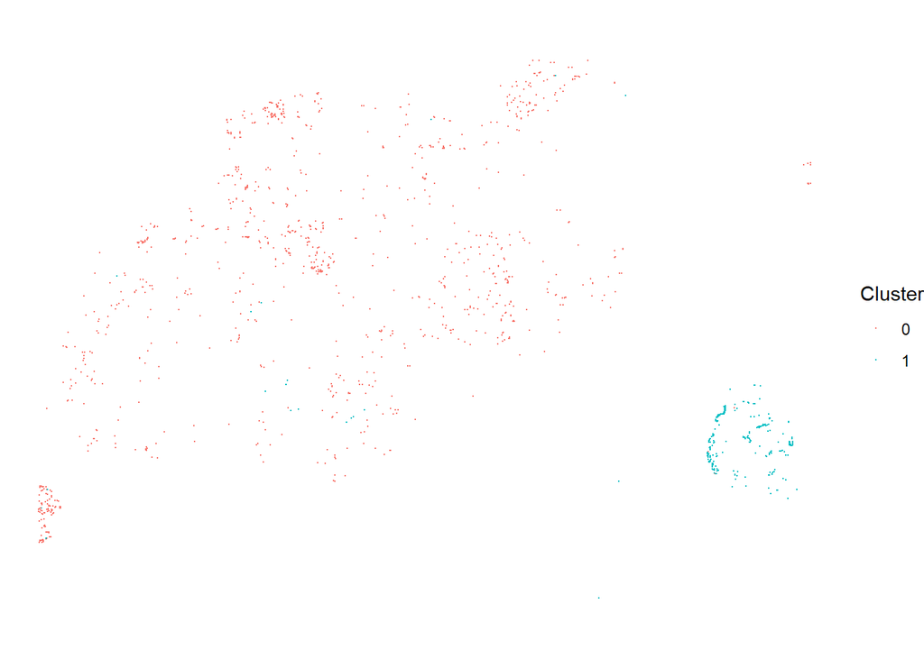

```r
spatial_subclusters
```

#### Cluster 0

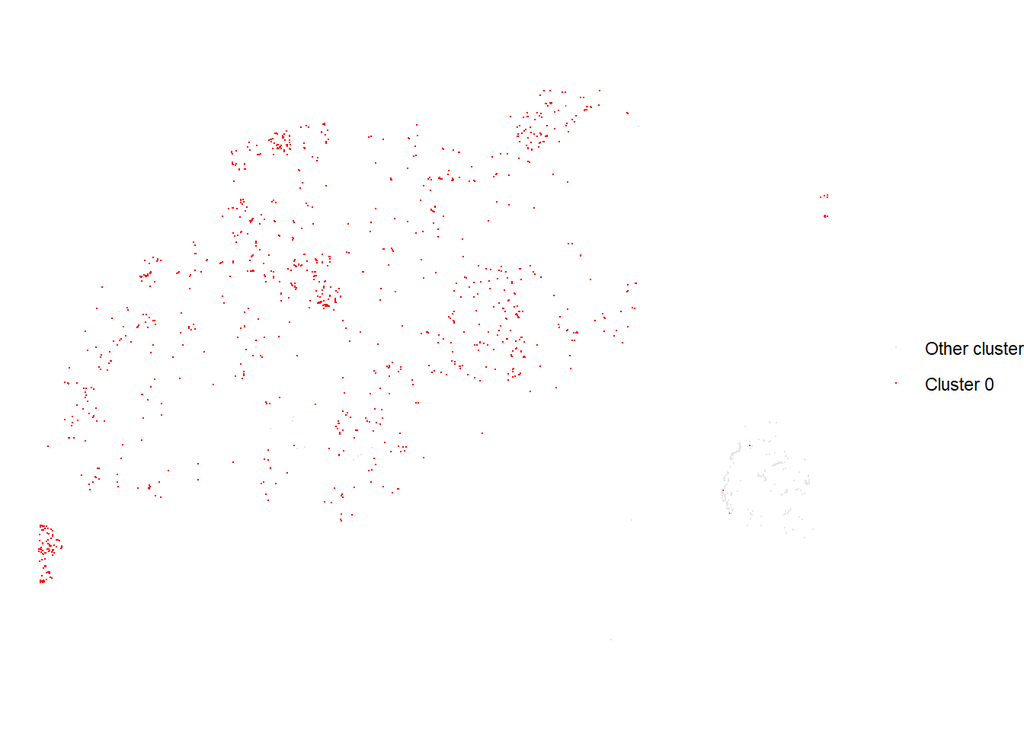

```r
cluster0_plot
```

#### Cluster 1

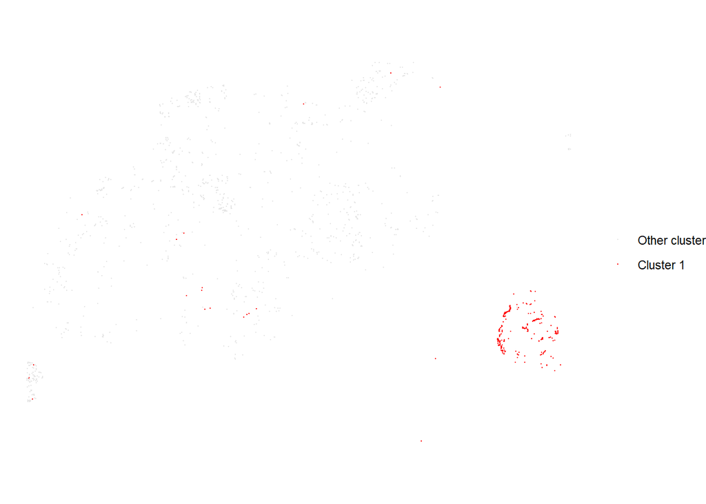

```r
cluster1_plot
```

### Markers

Differential expression analysis was performed to identify markers distinguishing the identified ciliated epithelial subclusters.

```r
# FindMarkers that distinguish identified clusters
Idents(cilia_obj) <- "seurat_clusters"

markers <- FindMarkers(cilia_obj,
                       ident.1 = "1",
                       ident.2 = "0",
                       assay = "Xenium",
                       slot = "data",
                       test.use = "wilcox")

top_cluster1_all <- markers %>%
  tibble::rownames_to_column("gene") %>%
  filter(avg_log2FC > 0, p_val_adj < 0.05) %>%
  arrange(p_val_adj)

top_cluster1 <- markers %>%
  tibble::rownames_to_column("gene") %>%
  filter(avg_log2FC > 0, p_val_adj < 0.05) %>%
  arrange(p_val_adj) %>%
  slice_head(n = 15)

top_cluster0_all <- markers %>%
  tibble::rownames_to_column("gene") %>%
  filter(avg_log2FC < 0,
         p_val_adj < 0.05) %>%
  arrange(p_val_adj)

top_cluster0 <- markers %>%
  tibble::rownames_to_column("gene") %>%
  filter(avg_log2FC < 0,
         p_val_adj < 0.05) %>%
  arrange(p_val_adj) %>%
  slice_head(n = 15)

kable(top_cluster1[, c("gene", "avg_log2FC", "p_val_adj")],
      caption = "Top markers enriched in Cluster 1")
```

Top markers enriched in Cluster 1

| gene | avg_log2FC | p_val_adj |
| --- | --- | --- |
| AGR2 | 6.651313 | 0 |
| PFKFB3 | 4.556289 | 0 |
| ERP27 | 5.863462 | 0 |
| KNDC1 | 5.133281 | 0 |
| C4B | 4.349247 | 0 |
| C4A | 4.310588 | 0 |
| C6 | 3.153304 | 0 |
| PDZD4 | 7.552026 | 0 |
| CCND2 | 5.320336 | 0 |
| TBX2 | 4.260681 | 0 |
| CD44 | 4.724084 | 0 |
| NXF3 | 4.761722 | 0 |
| SCIN | 4.792212 | 0 |
| HOXB6 | 4.213020 | 0 |
| WDR77 | 2.421447 | 0 |

```r
kable(top_cluster0[, c("gene", "avg_log2FC", "p_val_adj")],
      caption = "Top markers enriched in Cluster 0")
```

Top markers enriched in Cluster 0

| gene | avg_log2FC | p_val_adj |
| --- | --- | --- |
| UCHL1 | -6.546717 | 0 |
| MLF1 | -2.137037 | 0 |
| RBM38 | -2.237228 | 0 |
| CD47 | -2.098850 | 0 |
| IFT57 | -1.573751 | 0 |
| LAPTM4B | -2.353004 | 0 |
| YWHAZ | -1.588108 | 0 |
| PRKCI | -2.187912 | 0 |
| H19 | -2.292517 | 0 |
| NORAD | -1.205934 | 0 |
| SQLE | -1.989957 | 0 |
| MUC16 | -3.286836 | 0 |
| CFAP100 | -1.057106 | 0 |
| PLXNB1 | -1.111916 | 0 |
| CYP4B1 | -2.069103 | 0 |

### Cell type enrichment analysis

To further characterise the identified ciliated epithelial subclusters, marker genes from each cluster were analysed using Enrichr against the CellMarker and PanglaoDB reference databases. These databases were used to determine whether either cluster was enriched for annotated ciliated epithelial cell signatures or alternative cell states.

```r
# Cluster specific markers for enrichr
Idents(cilia_obj) <- "seurat_clusters"
all_markers <- FindAllMarkers(
  cilia_obj,
  only.pos = TRUE,
  assay = "Xenium",
  slot = "data",
  test.use = "wilcox")

cluster1_markers_enrichr <- all_markers %>%
  filter(cluster == "1", p_val_adj < 0.05) %>%
  arrange(desc(avg_log2FC))

cluster0_markers_enrichr <- all_markers %>%
  filter(cluster == "0", p_val_adj < 0.05) %>%
  arrange(desc(avg_log2FC))

# load databases
dbs <- c("CellMarker_Augmented_2021", "PanglaoDB_Augmented_2021")

# Run enrichr on both databases
enrich_cluster1 <- enrichr(cluster1_markers_enrichr$gene, dbs)
```

```
## Uploading data to Enrichr... Done.
##   Querying CellMarker_Augmented_2021... Done.
##   Querying PanglaoDB_Augmented_2021... Done.
## Parsing results... Done.
```

```r
enrich_cluster0 <- enrichr(cluster0_markers_enrichr$gene, dbs)
```

```
## Uploading data to Enrichr... Done.
##   Querying CellMarker_Augmented_2021... Done.
##   Querying PanglaoDB_Augmented_2021... Done.
## Parsing results... Done.
```

```r
cluster1_cellmarker <- enrich_cluster1$CellMarker_Augmented_2021 %>%
  arrange(Adjusted.P.value) %>%
  slice_head(n = 10)

cluster1_panglao <- enrich_cluster1$PanglaoDB_Augmented_2021 %>%
  arrange(Adjusted.P.value) %>%
  slice_head(n = 10)

cluster0_cellmarker <- enrich_cluster0$CellMarker_Augmented_2021 %>%
  arrange(Adjusted.P.value) %>%
  slice_head(n = 10)

cluster0_panglao <- enrich_cluster0$PanglaoDB_Augmented_2021 %>%
  arrange(Adjusted.P.value) %>%
  slice_head(n = 10)
```

### Enrichr results

#### Cluster 1 - CellMarker

```r
kable(head(cluster1_cellmarker, 10), caption = "Cluster 1 - CellMarker")
```

Cluster 1 - CellMarker

| Term | Overlap | P.value | Adjusted.P.value | Old.P.value | Old.Adjusted.P.value | Odds.Ratio | Combined.Score | Genes |
| --- | --- | --- | --- | --- | --- | --- | --- | --- |
| Endothelial cell:Cornea | 3/13 | 0.0000110 | 0.0044065 | 0 | 0 | 90.550000 | 1034.15771 | NT5E;LGR5;CD44 |
| Endometrial Stem cell:Endometrium | 3/23 | 0.0000662 | 0.0044065 | 0 | 0 | 45.252273 | 435.42916 | NT5E;LGR5;CD44 |
| Osteoblast:Bone | 3/24 | 0.0000755 | 0.0044065 | 0 | 0 | 43.095238 | 409.02553 | NT5E;CD44;TBX2 |
| Ciliated Epithelial cell:Esophagus | 8/425 | 0.0001048 | 0.0044065 | 0 | 0 | 6.137202 | 56.23918 | C20ORF85;DNAH1;NXF3;SPAG6;LDLRAD1;KNDC1;DNAH9;CCDC33 |
| Mesenchymal Stem cell:Amniotic Membrane | 2/5 | 0.0001165 | 0.0044065 | 0 | 0 | 198.288557 | 1795.99300 | NT5E;CD44 |
| Mesenchymal Stem cell:Embryonic Stem Cell | 2/5 | 0.0001165 | 0.0044065 | 0 | 0 | 198.288557 | 1795.99300 | NT5E;CD44 |
| Mesenchymal Stromal cell:Skeletal Muscle | 2/5 | 0.0001165 | 0.0044065 | 0 | 0 | 198.288557 | 1795.99300 | NT5E;CD44 |
| Mesenchymal Stem cell:Foreskin | 2/5 | 0.0001165 | 0.0044065 | 0 | 0 | 198.288557 | 1795.99300 | NT5E;CD44 |
| Mesenchymal Stromal cell:Umbilical Cord Blood | 2/5 | 0.0001165 | 0.0044065 | 0 | 0 | 198.288557 | 1795.99300 | NT5E;CD44 |
| Stromal cell:Adipose Tissue | 2/5 | 0.0001165 | 0.0044065 | 0 | 0 | 198.288557 | 1795.99300 | NT5E;CD44 |

#### Cluster 1 - PanglaoDB

```r
kable(head(cluster1_panglao, 10), caption = "Cluster 1 - PanglaoDB")
```

Cluster 1 - PanglaoDB

| Term | Overlap | P.value | Adjusted.P.value | Old.P.value | Old.Adjusted.P.value | Odds.Ratio | Combined.Score | Genes |
| --- | --- | --- | --- | --- | --- | --- | --- | --- |
| Ciliated Cells | 5/104 | 0.0000298 | 0.0031566 | 0 | 0 | 15.650253 | 163.10242 | C20ORF85;SPAG6;LDLRAD1;DNAH9;FAM216B |
| Ependymal Cells | 5/136 | 0.0001070 | 0.0056733 | 0 | 0 | 11.808206 | 107.95382 | C20ORF85;DNAH2;SPAG6;DNAH9;FAM216B |
| Ionocytes | 4/107 | 0.0005124 | 0.0120585 | 0 | 0 | 11.846453 | 89.75347 | C20ORF85;AGR2;DNAH9;FAM216B |
| Spermatozoa | 4/108 | 0.0005307 | 0.0120585 | 0 | 0 | 11.731953 | 88.47352 | C20ORF85;APOL6;HNMT;FAM216B |
| Follicular Cells | 4/110 | 0.0005688 | 0.0120585 | 0 | 0 | 11.509434 | 85.99831 | C6;RORC;AQP7;PLG |
| Intercalated Cells | 4/118 | 0.0007406 | 0.0130838 | 0 | 0 | 10.697436 | 77.10774 | DNAH2;SCIN;KCNJ16;DNAH9 |
| Fibroblasts | 5/232 | 0.0012365 | 0.0175643 | 0 | 0 | 6.781388 | 45.40480 | NT5E;TNXB;FMOD;SOD3;CD44 |
| Epsilon Cells | 4/138 | 0.0013256 | 0.0175643 | 0 | 0 | 9.091619 | 60.24002 | C6;AQP7;VSTM2L;HABP2 |
| Sertoli Cells | 4/158 | 0.0021756 | 0.0256236 | 0 | 0 | 7.902897 | 48.44837 | PFKFB3;NXF3;FMOD;SOD3 |
| Proximal Tubule Cells | 4/164 | 0.0024902 | 0.0263958 | 0 | 0 | 7.604231 | 45.59044 | SCIN;C6;SOD3;HABP2 |

#### Cluster 0 - CellMarker

```r
kable(head(cluster0_cellmarker, 10), caption = "Cluster 0 - CellMarker")
```

Cluster 0 - CellMarker

| Term | Overlap | P.value | Adjusted.P.value | Old.P.value | Old.Adjusted.P.value | Odds.Ratio | Combined.Score | Genes |
| --- | --- | --- | --- | --- | --- | --- | --- | --- |
| Natural Killer T (NKT) cell:Fetal Kidney | 167/4543 | 0.0e+00 | 0.0000000 | 0 | 0 | 3.018215 | 158.36253 | EIF4A1;KDM1A;PDCD6;ZFAND5;THUMPD3;CBLB;SMC4;FBL;EFR3A;FNTA;APMAP;PSMD2;KIF5B;PSMD3;RUVBL1;UBAP2L;KPNA2;HMGN3;AP2M1;SMARCC1;MBNL1;CSNK2A1;UBE4B;SDHA;SDHB;DPM1;MTAP;ILF3;DKC1;MAP7D1;NAAA;HECA;MXRA7;ADNP… |
| Progenitor cell:Undefined | 18/103 | 0.0e+00 | 0.0000000 | 0 | 0 | 12.108359 | 347.20801 | CCT3;EIF5A;EIF4A1;AHCY;SHMT2;TXNRD1;RPN1;NME1;CCT6A;GANAB;ALCAM;IRAK1;PSMD2;C1QBP;EIF4EBP1;KPNA2;CCT5;SNRPB |
| Mitotic Fetal Germ cell:Fetal Gonad | 34/650 | 0.0e+00 | 0.0000049 | 0 | 0 | 3.220939 | 55.92428 | PYGB;PDCD6;F11R;FSTL1;FBLN5;ELK3;LAPTM4B;FBL;TMEM123;PTDSS1;LDHA;SOX17;ERBB3;DPYSL2;C1QBP;SERPINH1;SURF6;MYBL2;PLTP;AP2M1;CTSA;TUBB;PTPN11;RHOC;MYCL;MAVS;PKM;APEX1;CLDN7;ANP32E;CD47;TKT;MYL9;TP53 |
| Cancer cell:Brain | 12/97 | 2.0e-07 | 0.0000223 | 0 | 0 | 7.933063 | 123.47221 | CCT6A;CCT3;SYNCRIP;PARP1;CSE1L;ACTL6A;CCT8;KPNA2;GART;CCT5;LRPPRC;HSPD1 |
| Villous cytotrophoblast:Placenta | 12/99 | 2.0e-07 | 0.0000224 | 0 | 0 | 7.749901 | 118.85754 | CCT6A;CCT3;ILF3;DNMT1;RFC4;KDM1A;PARP1;TUBB;RUVBL1;STMN1;GART;HSPD1 |
| Regulatory T (Treg) cell:Liver | 24/417 | 6.0e-07 | 0.0000541 | 0 | 0 | 3.498182 | 49.92337 | CTSA;KDM5B;TFRC;SDC4;GADD45A;CDKN2A;NCOA3;HNRNPLL;RHOC;SMC4;SLC5A3;ALDH3A2;LAPTM4B;MAP1LC3A;PKM;SUMO1;DPYSL2;KIF5B;TRPS1;UCP2;CTNNB1;PAK2;PLTP;CCDC50 |
| Lake Et al.Science.In8:Brain | 11/98 | 1.5e-06 | 0.0001117 | 0 | 0 | 7.083720 | 94.86511 | CCT6A;TOP2A;CCT3;TPX2;CCT2;CENPF;BIRC5;DSG2;KPNA2;MAPK15;CCT5 |
| Megakaryocyte Progenitor cell:Subcutaneous Adipose Tissue | 10/93 | 6.8e-06 | 0.0003149 | 0 | 0 | 6.732186 | 80.13827 | CCT6A;CCT2;TFRC;CSE1L;CCT8;GART;CCT5;LRPPRC;AURKA;HSPD1 |
| Erythroblast:Blood | 10/93 | 6.8e-06 | 0.0003149 | 0 | 0 | 6.732186 | 80.13827 | CCT6A;CCT2;TFRC;CSE1L;CCT8;GART;CCT5;LRPPRC;AURKA;HSPD1 |
| Mast Cell progenitor:Bone Marrow | 10/93 | 6.8e-06 | 0.0003149 | 0 | 0 | 6.732186 | 80.13827 | CCT6A;CCT2;TFRC;CSE1L;CCT8;GART;CCT5;LRPPRC;AURKA;HSPD1 |

#### Cluster 0 - PanglaoDB

```r
kable(head(cluster0_panglao, 10), caption = "Cluster 0 - PanglaoDB")
```

Cluster 0 - PanglaoDB

| Term | Overlap | P.value | Adjusted.P.value | Old.P.value | Old.Adjusted.P.value | Odds.Ratio | Combined.Score | Genes |
| --- | --- | --- | --- | --- | --- | --- | --- | --- |
| Reticulocytes | 14/103 | 0.0000000 | 0.0000006 | 0 | 0 | 8.888550 | 170.41719 | TFRC;PABPC4;SLC11A2;ILF3;LSG1;GANAB;POLR2B;RUVBL1;UBAP2L;TOPBP1;CCT8;GART;KPNB1;EIF4G1 |
| Embryonic Stem Cells | 15/176 | 0.0000007 | 0.0000483 | 0 | 0 | 5.260330 | 74.32150 | YAP1;YES1;PAWR;LAMC1;FSTL1;PTK2;PTPRG;LAPTM4B;GJA1;TRIM28;SERPINH1;CTNNB1;AMOTL2;DSG2;LGR4 |
| Undefined Placental Cells | 10/108 | 0.0000255 | 0.0011240 | 0 | 0 | 5.697376 | 60.24981 | CCT3;EIF5A;H19;AHCY;TFRC;TRIM28;SHMT2;PSMD3;DSG2;MAPK15 |
| Podocytes | 12/184 | 0.0001315 | 0.0043406 | 0 | 0 | 3.902967 | 34.87789 | YAP1;WWTR1;GJA1;ITGB5;CTTN;AMOTL2;LAMC1;SULF1;FSTL1;LGR4;PTPRG;VEGFA |
| Pluripotent Stem Cells | 9/112 | 0.0001935 | 0.0051087 | 0 | 0 | 4.863580 | 41.58449 | SMARCC1;HDAC2;CENPF;RFC4;KDM1A;PARP1;SRSF1;GMPS;PSIP1 |
| Pulmonary Alveolar Type I Cells | 9/131 | 0.0006182 | 0.0136002 | 0 | 0 | 4.102144 | 30.30955 | YAP1;WWTR1;SDC4;MAL2;CYP4B1;AMOTL2;PLXNB1;EMP2;VEGFA |
| Satellite Cells | 9/139 | 0.0009455 | 0.0148374 | 0 | 0 | 3.848126 | 26.79746 | YAP1;WWTR1;DAG1;TIMP3;ITGA7;SCRIB;AMOTL2;LAMC1;FSTL1 |
| Granulosa Cells | 8/112 | 0.0009547 | 0.0148374 | 0 | 0 | 4.269231 | 29.68884 | YAP1;CTTN;ADAMTS1;DAG1;SERPINH1;AMOTL2;LAMC1;FSTL1 |
| Cardiac Stem And Precursor Cells | 8/113 | 0.0010116 | 0.0148374 | 0 | 0 | 4.228355 | 29.15951 | YAP1;LAPTM4B;WWTR1;SERPINH1;AMOTL2;LAMC1;FSTL1;PTPRG |
| Adipocyte Progenitor Cells | 8/115 | 0.0011337 | 0.0149652 | 0 | 0 | 4.148896 | 28.13884 | YAP1;WWTR1;ADAMTS1;SERPINH1;TIMP3;AMOTL2;LAMC1;FSTL1 |

## Assign Ciliated cell types

Based on the spatial distribution, marker expression patterns and enrichment analyses, subcluster 0 was reannotated as Tumour Associated Ciliated Epithelial Cells.

```r
# Assign refined annotation
xenium.obj$cell_type_refined <- xenium.obj$cell_type

# Get cells belonging to cluster 0
cluster0_cells <- Cells(cilia_obj)[cilia_obj$seurat_clusters == "0"]

# Replace annotation
xenium.obj$cell_type_refined[cluster0_cells] <- "Tumour Associated Ciliated Epithelial Cells"

# Show refined cell types
table(xenium.obj$cell_type_refined)
```

```
##
##                   Ciliated Epithelial Cells
##                                         264
##                           Endothelial Cells
##                                       20568
##                   Fallopian Tube Epithelium
##                                        1939
##                             Granulosa Cells
##                                        1854
##                    Inflammatory Tumor Cells
##                                        1395
##                                 Macrophages
##                                       27248
##                 Malignant Cells Lining Cyst
##                                        2119
##              MT-High, Jun+/Fos+ Tumor Cells
##                                       99633
##                                   Pericytes
##                                       18408
##                   Proliferative Tumor Cells
##                                       20262
##                         Smooth Muscle Cells
##                                       48827
##              Stromal Associated Fibroblasts
##                                       25339
##                                T & NK Cells
##                                       13577
##                Tumor Associated Fibroblasts
##                                       47538
##                                 Tumor Cells
##                                       16430
## Tumour Associated Ciliated Epithelial Cells
##                                        1027
##                          VEGFA+ Tumor Cells
##                                       60183
```

## Fallopian Tube Epithelium refinement

### Secretory Epithelial Cells annotation

Secretory Epithelial Cells were identified within the Fallopian Tube Epithelium population based on detectable PAX8 expression and annotated as a separate cell type. PAX8 is a recognised marker of secretory fallopian tube epithelial cells.

```r
# Subset Fallopian Tube Epithelium
FT_obj <- subset(xenium.obj, subset = cell_type == "Fallopian Tube Epithelium")

# Retrieve normalised PAX8 expression levels
expr <- FetchData(FT_obj, vars = "PAX8")

# Default label
FT_obj$FT_subtype <- "Fallopian Tube Epithelium"

# Secretory cells
FT_obj$FT_subtype[expr$PAX8 > 0] <- "Secretory Epithelial Cells"

# Summary
table(FT_obj$FT_subtype)
```

```
##
##  Fallopian Tube Epithelium Secretory Epithelial Cells
##                       1179                        760
```

```r
prop.table(table(FT_obj$FT_subtype)) * 100
```

```
##
##  Fallopian Tube Epithelium Secretory Epithelial Cells
##                   60.80454                   39.19546
```

```r
# Annotate Secretory Epithelial Cells in main object
# Get Secretory Epithelial Cells
secretory_cells <- Cells(FT_obj)[FT_obj$FT_subtype == "Secretory Epithelial Cells"]

# Replace annotation
xenium.obj$cell_type_refined[secretory_cells] <- "Secretory Epithelial Cells"

# Show refined cell types
table(xenium.obj$cell_type_refined)
```

```
##
##                   Ciliated Epithelial Cells
##                                         264
##                           Endothelial Cells
##                                       20568
##                   Fallopian Tube Epithelium
##                                        1179
##                             Granulosa Cells
##                                        1854
##                    Inflammatory Tumor Cells
##                                        1395
##                                 Macrophages
##                                       27248
##                 Malignant Cells Lining Cyst
##                                        2119
##              MT-High, Jun+/Fos+ Tumor Cells
##                                       99633
##                                   Pericytes
##                                       18408
##                   Proliferative Tumor Cells
##                                       20262
##                  Secretory Epithelial Cells
##                                         760
##                         Smooth Muscle Cells
##                                       48827
##              Stromal Associated Fibroblasts
##                                       25339
##                                T & NK Cells
##                                       13577
##                Tumor Associated Fibroblasts
##                                       47538
##                                 Tumor Cells
##                                       16430
## Tumour Associated Ciliated Epithelial Cells
##                                        1027
##                          VEGFA+ Tumor Cells
##                                       60183
```

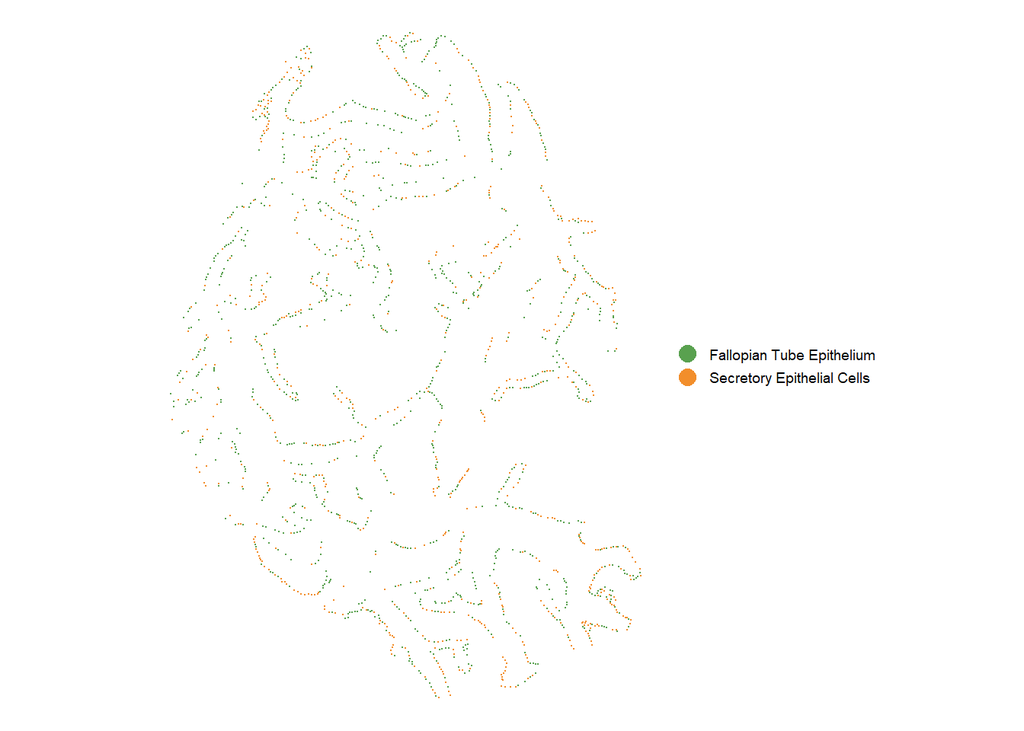

```r
# Plot refined cell annotation in normal region
# Subset normal fallopian tube region
box <- list(xmin = 7800, xmax = 10100, ymin = 3750, ymax = 6050)

coords <- GetTissueCoordinates(xenium.obj, image = "fov")

cells_keep <- colnames(xenium.obj)[coords$x > box$xmin &
                                     coords$x < box$xmax &
                                     coords$y > box$ymin &
                                     coords$y < box$ymax]

FT_obj_normal <- subset(FT_obj, cells = cells_keep)

# Plot refined cell annotation in normal region
plot_ft_normal <- cbind(FT_obj_normal@meta.data, GetTissueCoordinates(FT_obj_normal, image = "fov"))

ft_cols <- c("Secretory Epithelial Cells" = "#F28E2B",
             "Fallopian Tube Epithelium" = "#59A14F")

ggplot(plot_ft_normal,
       aes(x = x,  y = y,  col = FT_subtype)) +
  geom_point(size = 1/3, stroke = 0) +
  coord_equal() +
  theme_void() +
  scale_y_reverse() +
  scale_color_manual(values = ft_cols) +
  guides(color = guide_legend(
    override.aes = list(size = 4),
    ncol = 1)) +
  theme(legend.position = "right",
        legend.text = element_text(size = 7),
        legend.title = element_blank(),
        legend.key.height = unit(2, "mm"),
        legend.key.width = unit(1, "mm"))
```

## Export

### Standardise nomenclature

```r
# British spelling
xenium.obj$cell_type_refined <- recode(xenium.obj$cell_type_refined,
                                       "Tumor Cells" = "Tumour Cells",
                                       "Proliferative Tumor Cells" = "Proliferative Tumour Cells",
                                       "VEGFA+ Tumor Cells" = "VEGFA+ Tumour Cells",
                                       "Inflammatory Tumor Cells" = "Inflammatory Tumour Cells",
                                       "MT-High, Jun+/Fos+ Tumor Cells" = "MT-High, Jun+/Fos+ Tumour Cells",
                                       "Tumor Associated Fibroblasts" = "Tumour Associated Fibroblasts")
```

### Master export

```r
cell_type_refined <- data.frame(cell_id = colnames(xenium.obj),
                                group = xenium.obj$cell_type_refined)

head(cell_type_refined)
```

```
##               cell_id                           group
## aaaaebmm-1 aaaaebmm-1      Proliferative Tumour Cells
## aaaafhpp-1 aaaafhpp-1 MT-High, Jun+/Fos+ Tumour Cells
## aaaahcem-1 aaaahcem-1      Proliferative Tumour Cells
## aaaakeoi-1 aaaakeoi-1             VEGFA+ Tumour Cells
## aaaalald-1 aaaalald-1 MT-High, Jun+/Fos+ Tumour Cells
## aaaalomf-1 aaaalomf-1 MT-High, Jun+/Fos+ Tumour Cells
```

```r
write.csv(cell_type_refined, "Data/cell_type_refined.csv", row.names = FALSE)
```

## Visualisation

The final refined cell type annotations are visualised spatially below.

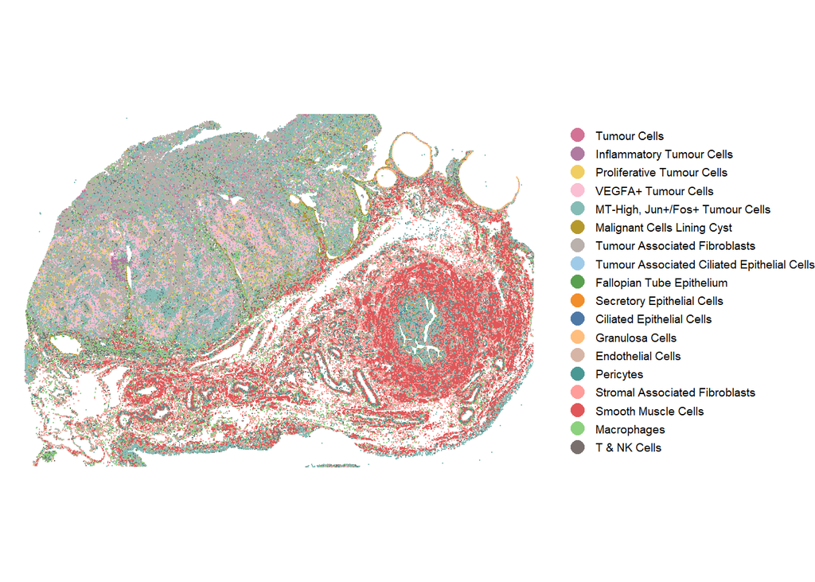

```r
# View final annotated cells using ggplot2
plot_annotated <- cbind(xenium.obj@meta.data, GetTissueCoordinates(xenium.obj, image = "fov"))

# Set manual colours from palette
manual_col <- c("Proliferative Tumour Cells" = "#F1CE63",
                "MT-High, Jun+/Fos+ Tumour Cells" = "#86BCB6",
                "VEGFA+ Tumour Cells" = "#FABFD2",
                "Tumour Cells" = "#D37295",
                "Fallopian Tube Epithelium" = "#59A14F",
                "Macrophages" = "#8CD17D",
                "Tumour Associated Ciliated Epithelial Cells" = "#A0CBE8",
                "Ciliated Epithelial Cells" = "#4E79A7",
                "T & NK Cells" = "#79706E",
                "Tumour Associated Fibroblasts" = "#BAB0AC",
                "Malignant Cells Lining Cyst" = "#B6992D",
                "Endothelial Cells" = "#D7B5A6",
                "Stromal Associated Fibroblasts" = "#FF9D9A",
                "Pericytes" = "#499894",
                "Smooth Muscle Cells" = "#E15759",
                "Inflammatory Tumour Cells" = "#B07AA1",
                "Granulosa Cells" = "#FFBE7D",
                "Secretory Epithelial Cells" = "#F28E2B")

# Add legend order
legend_order <- c("Tumour Cells", "Inflammatory Tumour Cells", "Proliferative Tumour Cells", "VEGFA+ Tumour Cells", "MT-High, Jun+/Fos+ Tumour Cells", "Malignant Cells Lining Cyst", "Tumour Associated Fibroblasts", "Tumour Associated Ciliated Epithelial Cells", "Fallopian Tube Epithelium", "Secretory Epithelial Cells", "Ciliated Epithelial Cells", "Granulosa Cells","Endothelial Cells", "Pericytes", "Stromal Associated Fibroblasts", "Smooth Muscle Cells", "Macrophages", "T & NK Cells")

ggplot(plot_annotated, aes(x = x, y = y, col = cell_type_refined)) +
  geom_point(size = 1/3, stroke = 0) +
  coord_equal() +
  theme_void() +
  scale_y_reverse() + # flip y axis
  scale_color_manual(values = manual_col, breaks = legend_order) +
  guides(color = guide_legend(
    override.aes = list(size = 4),
    ncol = 1)) +
  theme(legend.position = "right",
        legend.text  = element_text(size = 7),
        legend.title = element_blank(),
        legend.key.height = unit(2, "mm"),
        legend.key.width  = unit(1, "mm"))
```

```r
# Global limits for entire dataset
xlim_all <- range(plot_annotated$x, na.rm = TRUE)
ylim_all <- range(plot_annotated$y, na.rm = TRUE)

plot_cell_type <- function(ct) {
  ggplot(subset(plot_annotated, cell_type_refined == ct),
         aes(x = x, y = y)) +
    geom_point(color = manual_col[ct],
               size = 1/3,
               stroke = 0) +
    coord_equal(xlim = xlim_all,
                ylim = ylim_all) +
    theme_void() +
    scale_y_reverse() +
    ggtitle(ct) +
    theme(plot.title = element_text(size = 10,
                                    hjust = 0.5),
          legend.position = "none"
    )
}

cell_types <- unique(plot_annotated$cell_type_refined)
plots <- lapply(cell_types, plot_cell_type)
names(plots) <- cell_types
```

### Highlight cell types separately

#### Proliferative Tumour Cells

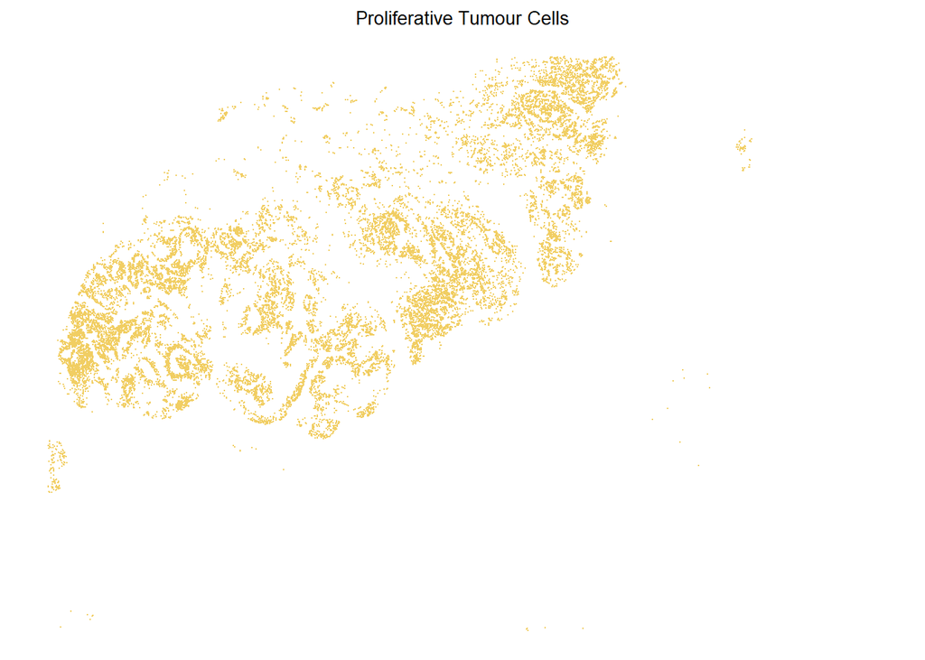

#### MT-High, Jun+/Fos+ Tumour Cells

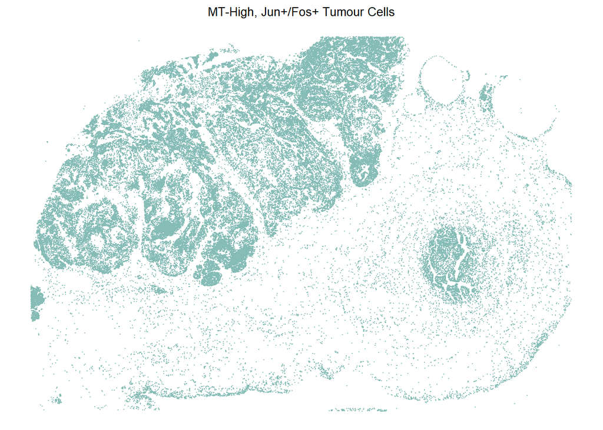

#### VEGFA+ Tumour Cells

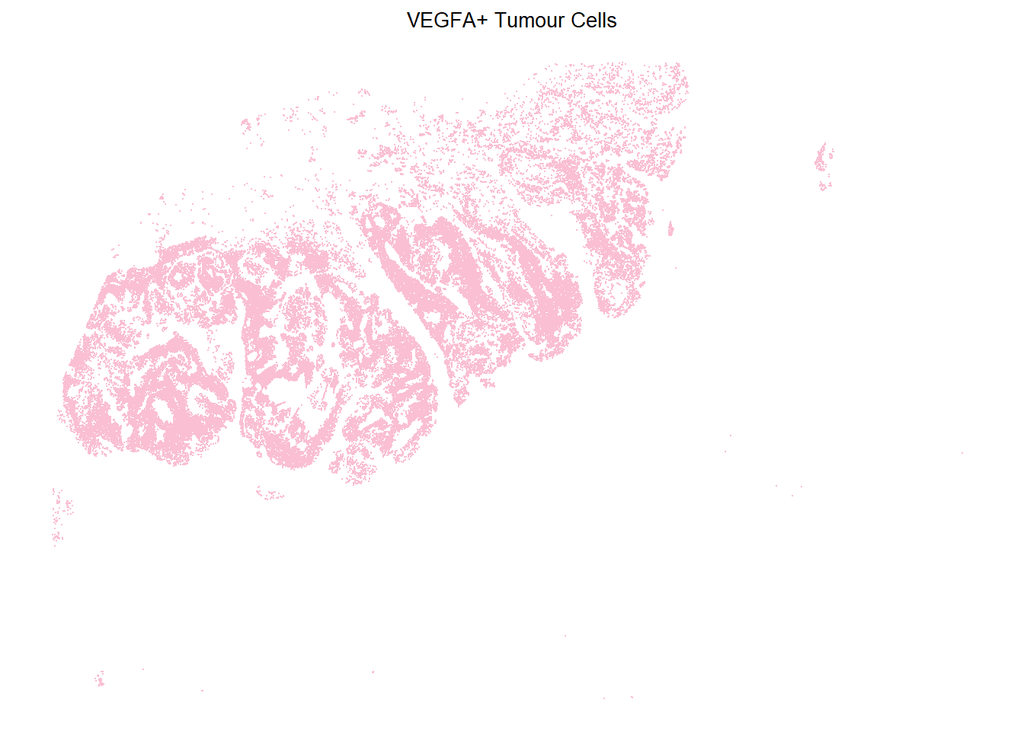

#### Tumour Cells

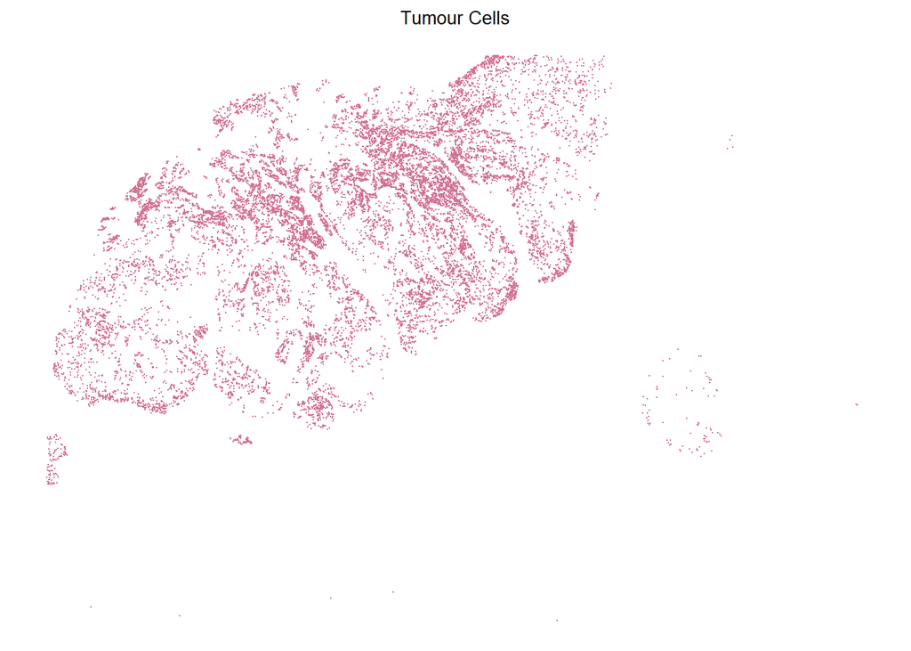

#### Macrophages

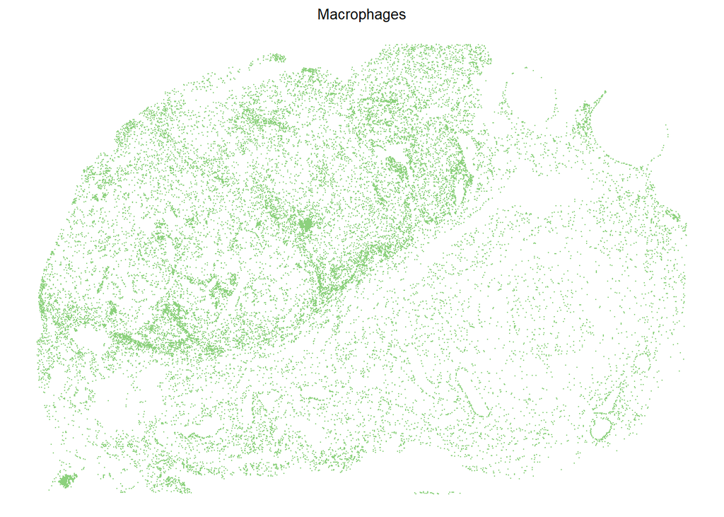

#### Tumour Associated Ciliated Epithelial Cells

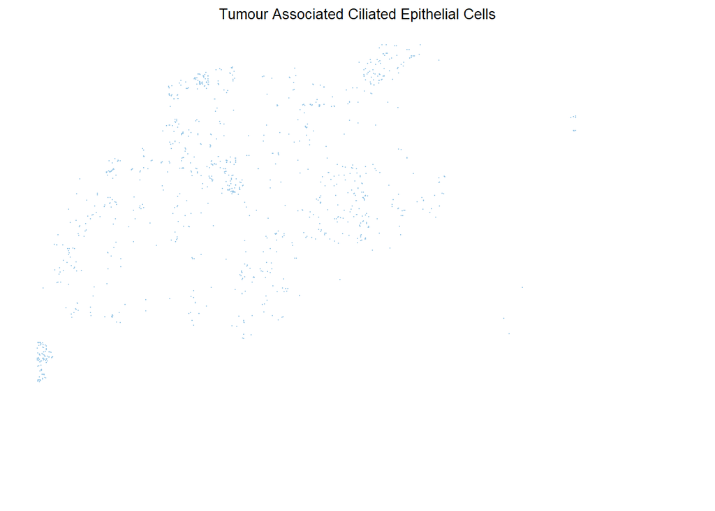

#### T & NK Cells

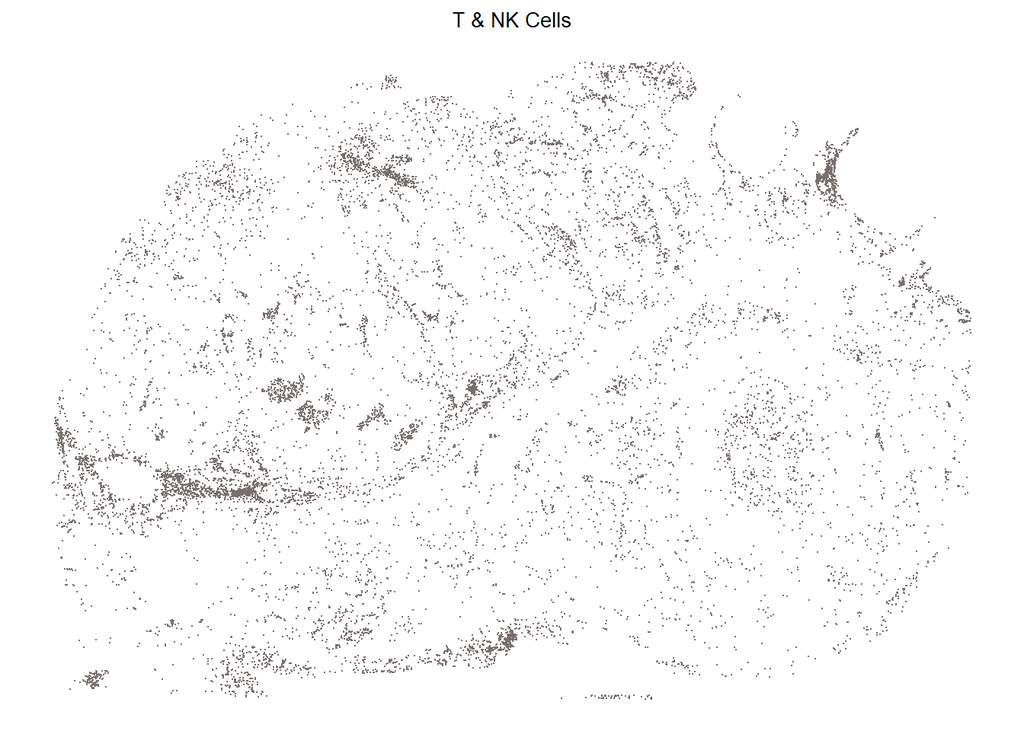

#### Tumour Associated Fibroblasts

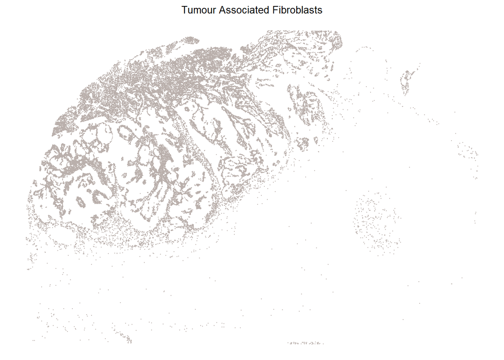

#### Malignant Cells Lining Cyst

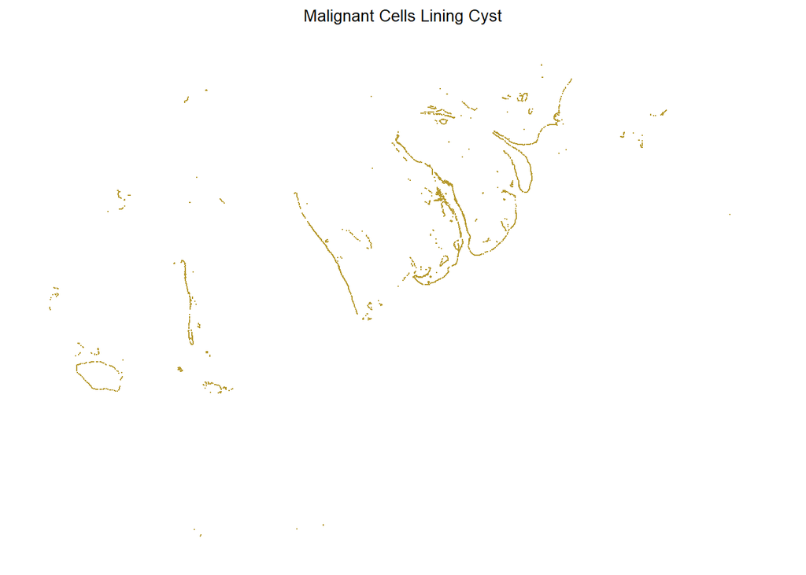

#### Endothelial Cells

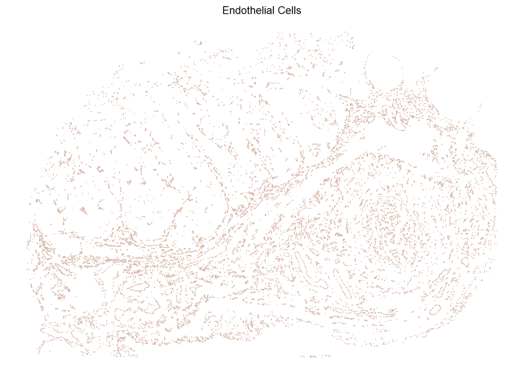

#### Fallopian Tube Epithelium

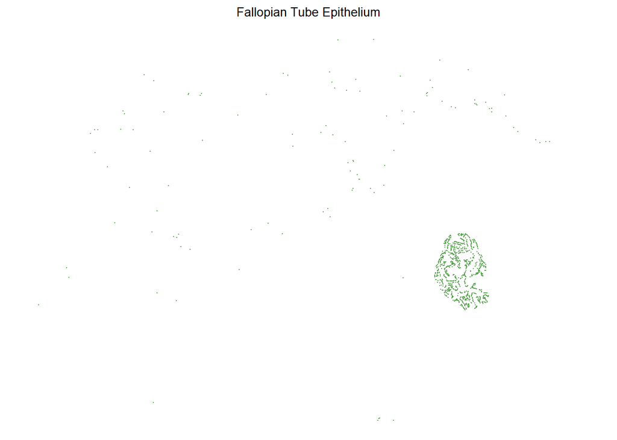

#### Stromal Associated Fibroblasts

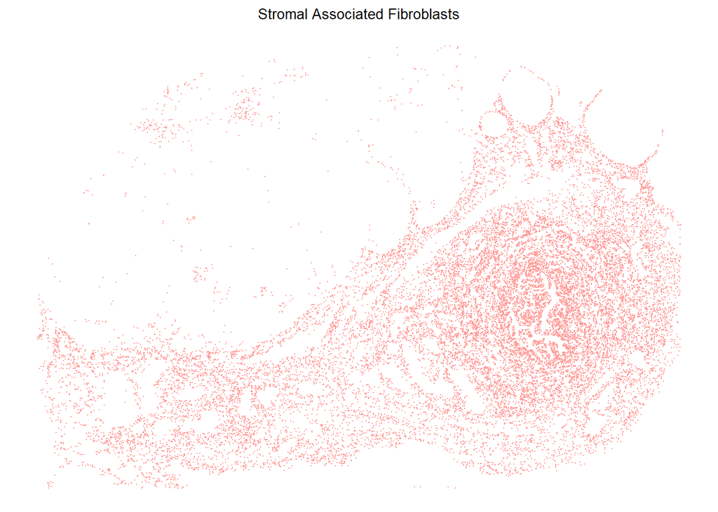

#### Pericytes

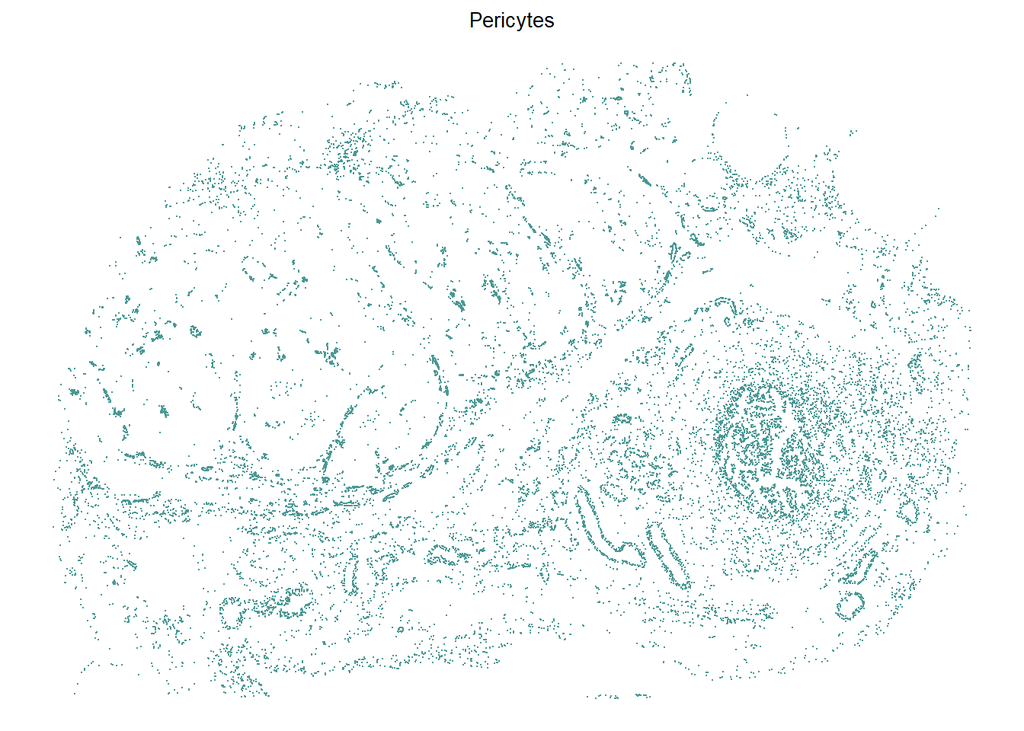

#### Smooth Muscle Cells

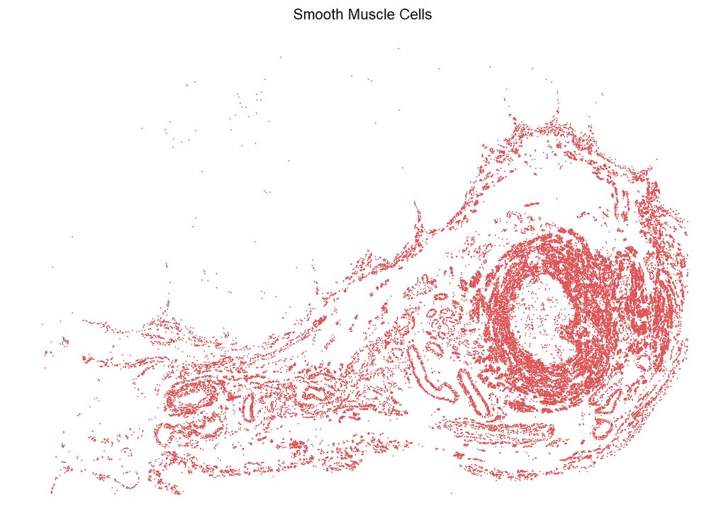

#### Inflammatory Tumour Cells

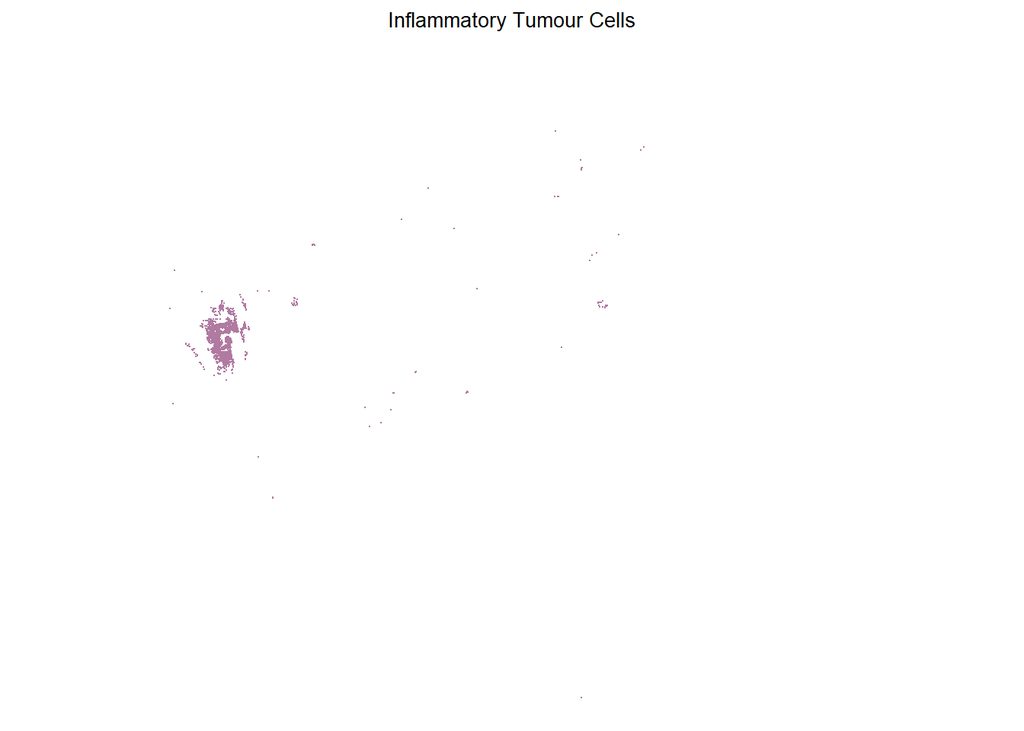

#### Granulosa Cells

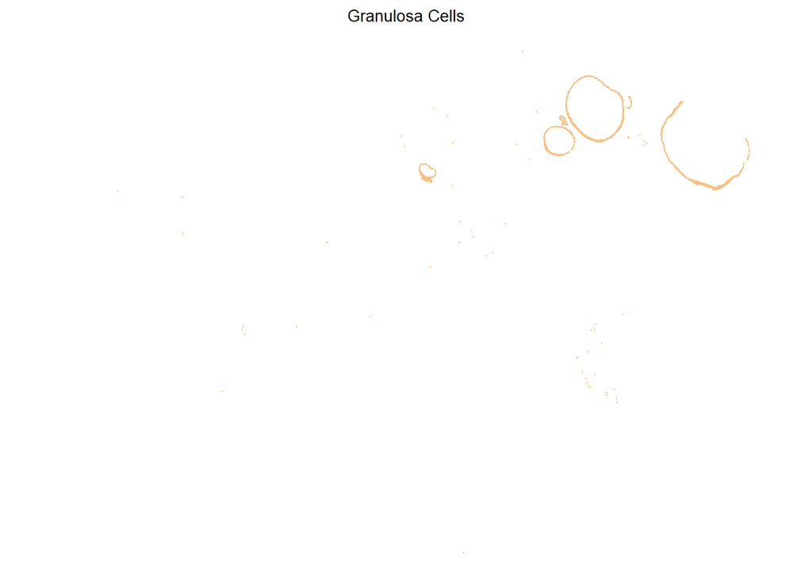

#### Secretory Epithelial Cells

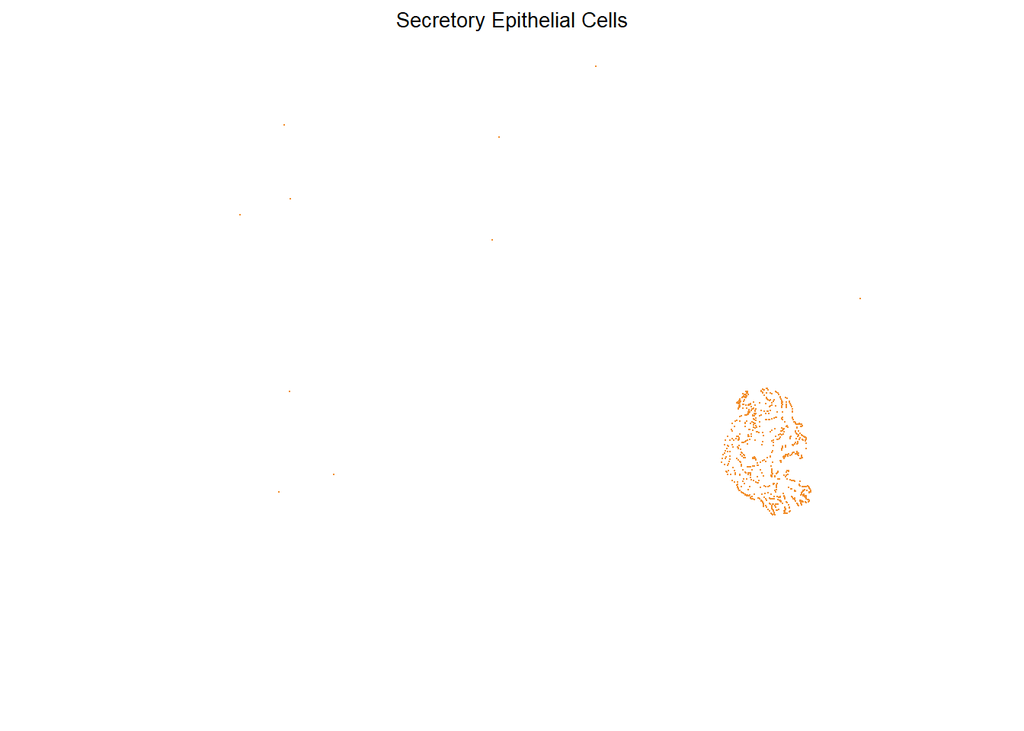

#### Ciliated Epithelial Cells

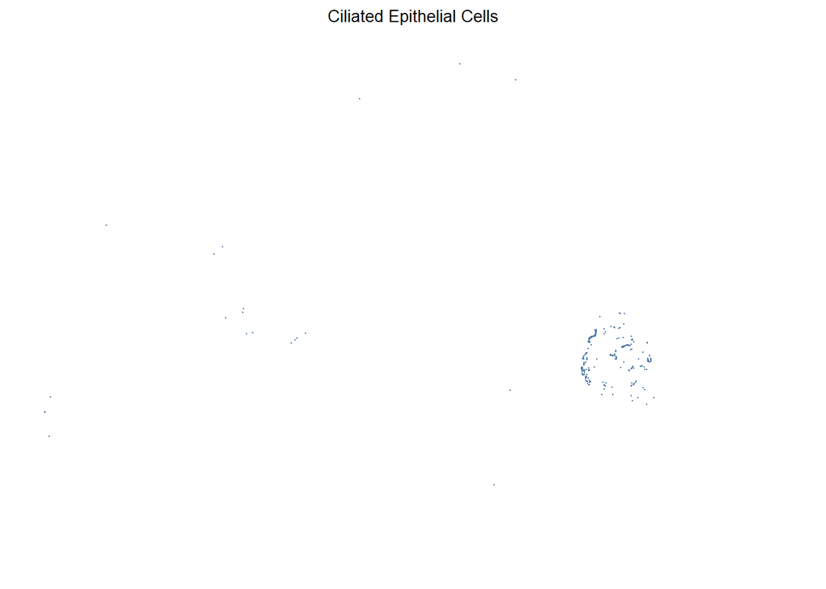

## Summary

The initial cell type annotations generated using the 10x Genomics label transfer workflow were refined.

Ciliated Epithelial Cells segregated into two distinct subpopulations. One population localised predominantly within the histologically normal fallopian tube epithelium and retained a canonical ciliated epithelial transcriptional profile.. The second population was enriched outside the normal fallopian tube region and was therefore reannotated as Tumour Associated Ciliated Epithelial Cells.

In addition, Secretory Epithelial Cells were identified within the Fallopian Tube Epithelium population using PAX8 expression and annotated as a separate cell type.

The refined annotations generated here were used in all downstream analyses.